# Cyclistic Bike-Share Analysis Case Study Data Analysis

Mphatso Senezio

2024-08-17

## Introduction

- I analyzed the usage patterns of annual members and casual riders of Cyclistic, a bike-share company in Chicago.
- The analysis involved cleaning and manipulating a large dataset to uncover key insights.
- The findings revealed that casual riders are more likely to take longer rides, especially on weekends and late at night.
- I have proposed three recommendations aimed at converting casual riders into loyal members through targeted marketing and optimized service offerings.

## What?

- “How do annual members and casual riders use Cyclistic bikes differently?”
- Understanding the differences in bike usage between these two groups would help tailor marketing strategies to convert casual riders into annual members.
- To address this question, I needed to gather comprehensive data on bike usage, ensure its quality, and analyze it to uncover meaningful insights.

## Data Collection, Organization, and Integrity (Prepare)

- Data required for this analysis was from Divvy’s official source.
- The data included ride details for several months, covering a wide range of bike trips.
- The data met the ROCK criteria—Reliable, Original, Comprehensive, Current, and Cited.
- It was sourced directly from Divvy and was up-to-date

### Organization of the data

- I organized the data by downloading and combining multiple CSV files from August 2023 through July 2024.
- Each file represented a month’s worth of bike trip data.
- The data was structured with various attributes, including ride IDs, bike types, timestamps, and station information.

### Data integrity

I verified the data’s integrity by checking for any issues or inconsistencies that might affect the analysis. This step was crucial to ensure that the data was ready for the next stages of processing and analysis.

## Data Cleaning and Transformation (Process)

In the data preparation phase, I focused on cleaning and transforming the dataset to ensure its readiness for analysis. I performed the following steps:

- **Loading and Combining Data**: I used R to load and combine the monthly datasets into a single data frame.
- **Cleaning the Data**: I identified and resolved issues related to station IDs and names. By creating lookup tables and resolving duplicates, I ensured that all station names were correctly matched and filled in where missing.
- **Handling Missing and Invalid Data**: I filtered out rows with missing or invalid data. This included removing rides with zero or negative lengths and optionally removing rides with durations of 10 seconds or less to ensure only meaningful data was included.

### **Creating New Columns**

I added new columns to enhance the dataset:

1. **ride_length**: Calculated as the difference between ended_at and started_at.
2. **day_of_week**: Extracted from the start timestamp to analyze usage patterns by day.
3. **Final Checks**: I reviewed the cleaned dataset to ensure it was free of errors and ready for analysis. This included calculating summary statistics such as the mean, maximum, and mode of ride lengths and days of the week.

|  | Metric | Value |
| --- | --- | --- |
| 1 | Mean Ride Length | 998 secs |
| 2 | Max Ride Length | 413473 secs |
| 3 | Mode Day of the Week | Wednesday |

I prepared a clean, comprehensive dataset that was suitable for analyzing bike usage patterns between annual members and casual riders. This ensured that the insights derived from the analysis would be accurate and reliable.

## Descriptive Analysis(Analyze)

Now that the data has been cleaned and transformed, it’s time to analyze it to uncover meaningful insights. Here’s how the analysis was conducted, the findings, and their implications:

#### 1. Proportional Share of Rides by Member Type

- I calculated the proportional share of rides by member type.
- Annual members account for approximately 64.8% of the rides, while casual riders make up 35.2%.
- This distribution highlights that while annual members contribute to a larger portion of the rides, casual riders still represent a significant segment.

|  | member_casual | total_rides | proportion |
| --- | --- | --- | --- |
| 1 | casual | 1486059 | 0.3516438817103696 |
| 2 | member | 2739975 | 0.6483561182896305 |

A pie chart below was created to visually represent the proportional share of rides. This chart clearly illustrates the dominance of *annual members* in the bike-share program.

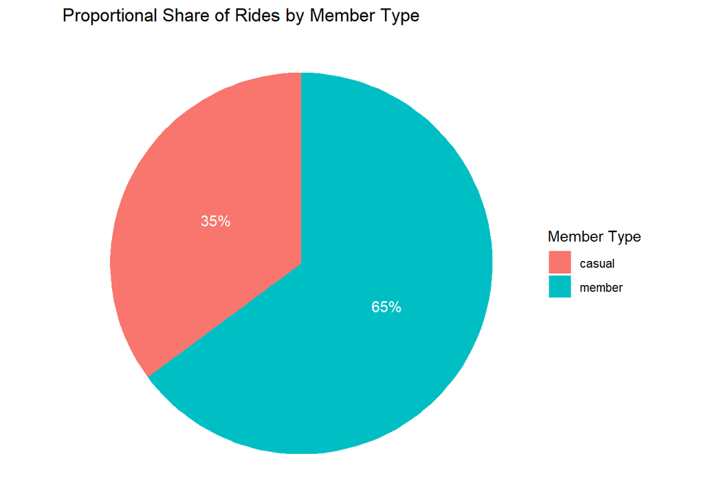

#### 2. Analysis of Short Rides

|  | member_casual | count |
| --- | --- | --- |
| 1 | casual | 16074 |
| 2 | member | 30671 |

### 3. Bike Usage by Type and Member Type

The analysis of ride counts by rideable type and member type shows distinct patterns in bike utilization:

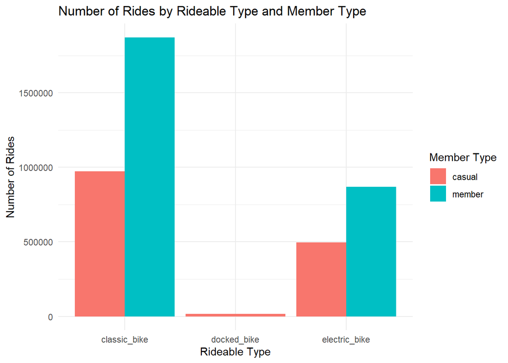

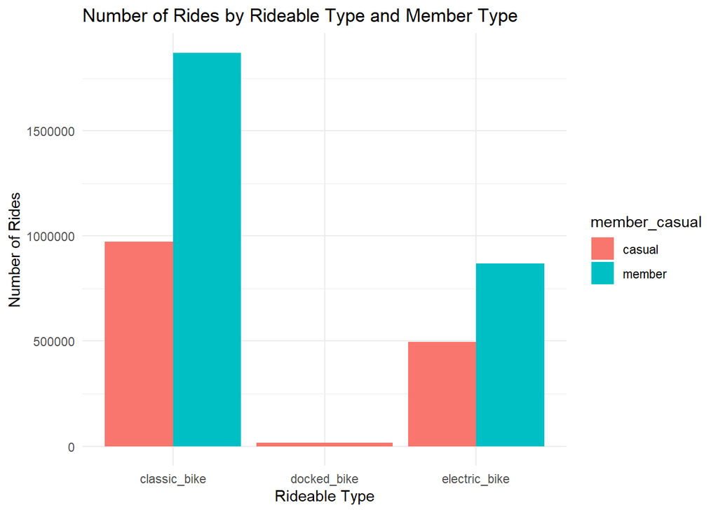

### Summary of Analysis

These insights reveal distinct usage patterns between casual riders and annual members, providing a foundation for targeted marketing strategies aimed at converting casual riders into annual members. Understanding these patterns will help tailor promotions and improve member engagement.

## Analyzing Trends and Insights

In this section, I delved into the various trends and insights derived from the Cyclistic bike-share data. This analysis aims to uncover patterns in bike usage that could inform strategic decisions for enhancing user experience and optimizing service delivery.

### 1. Average Ride Length by Day of the Week

- Casual riders consistently have longer ride lengths compared to annual members across all days.
- *On Sundays*, casual riders have an average ride length of approximately 1666 seconds, whereas annual members have an average of about 846 seconds.

This indicates that casual riders might be using the bikes for longer trips, possibly for leisure or exploration, while annual members might be using them for shorter, more frequent trips.

A bar plot below illustrates these differences, highlighting the variation in average ride length between casual and annual members throughout the week.

```
## Defaulting to continuous.
```

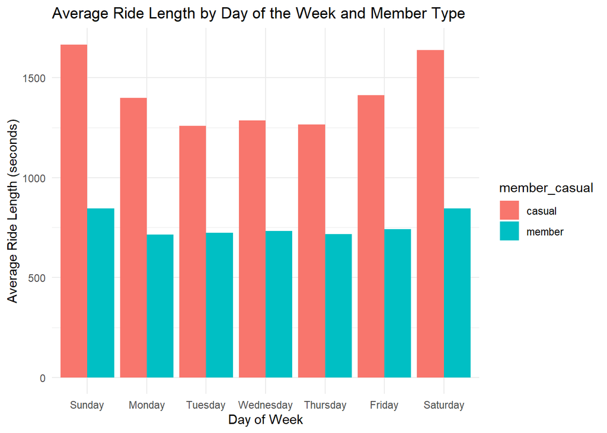

### 2. Number of Rides by Hour of the Day

|  | hour_of_day | member_casual | ride_count |
| --- | --- | --- | --- |
| 1 | 0 | casual | 21824 |
| 2 | 0 | member | 21167 |
| 3 | 1 | casual | 14499 |
| 4 | 1 | member | 11993 |
| 5 | 2 | casual | 8588 |
| 6 | 2 | member | 6605 |
| 7 | 3 | casual | 4642 |
| 8 | 3 | member | 4397 |
| 9 | 4 | casual | 3485 |
| 10 | 4 | member | 5755 |

[output cut: 38 more lines]

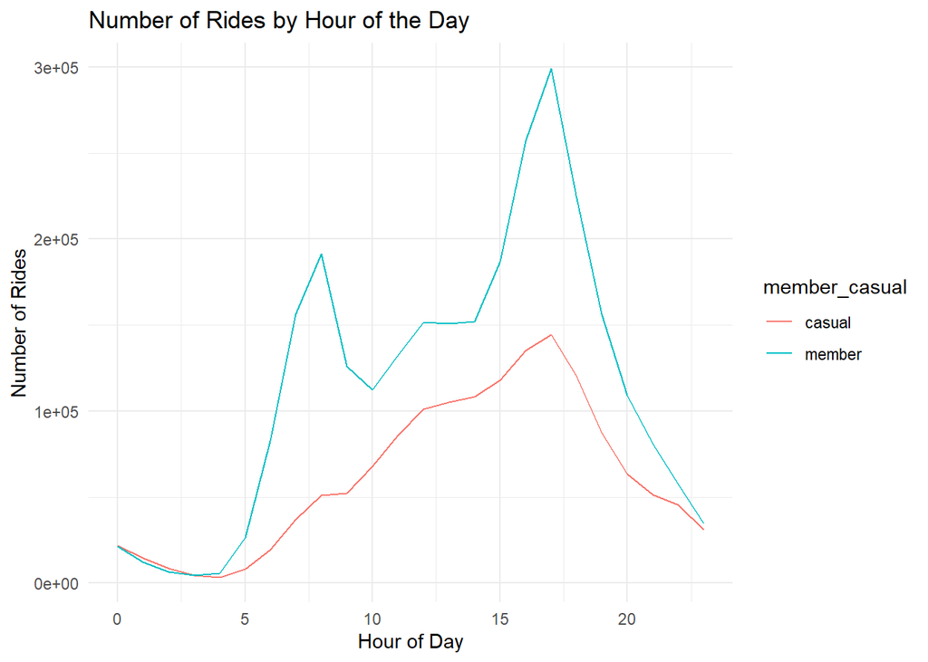

### 3. Most Popular Start and End Stations

The analysis identified the top 10 most popular start and end stations. The most frequented start station is “**Streeter Dr & Grand Ave**,” and the most frequented end station is the same location. These stations serve as key hubs for bike-share activity.

- **Start Stations**: A bar plot shows the top start stations.

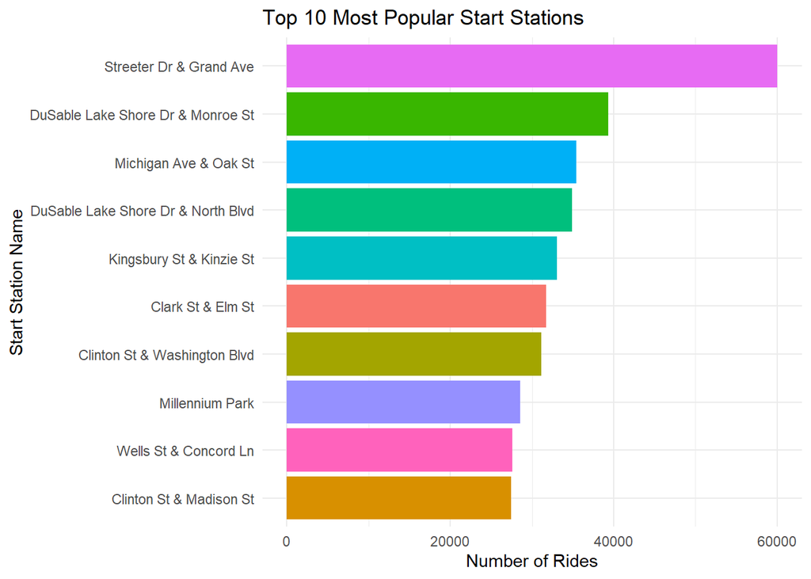

- **End Stations:** A similar bar plot displays the top end stations.

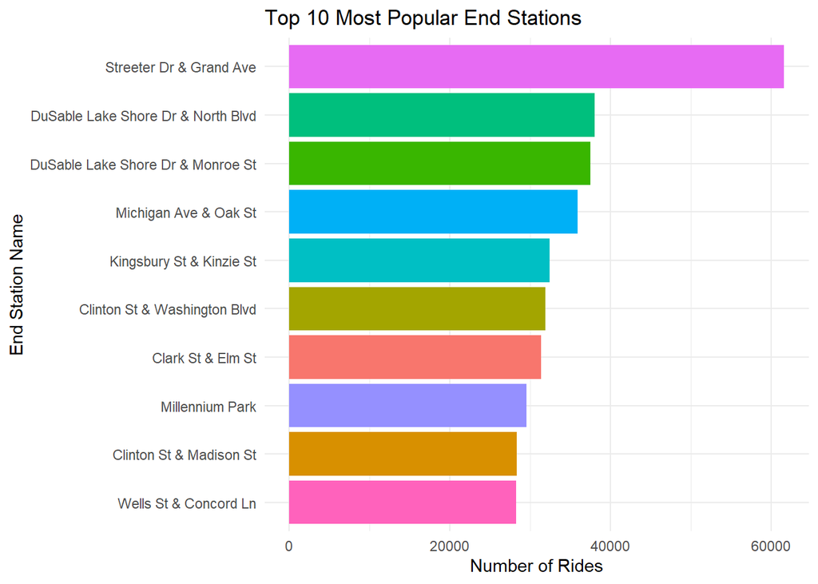

### 4. Top Stations by Member Type

Breaking down popular start and end stations by member type revealed differences in preferences. For instance, annual members favor stations closer to their residences or regular routes, while casual riders might use different stations depending on their specific trip needs.

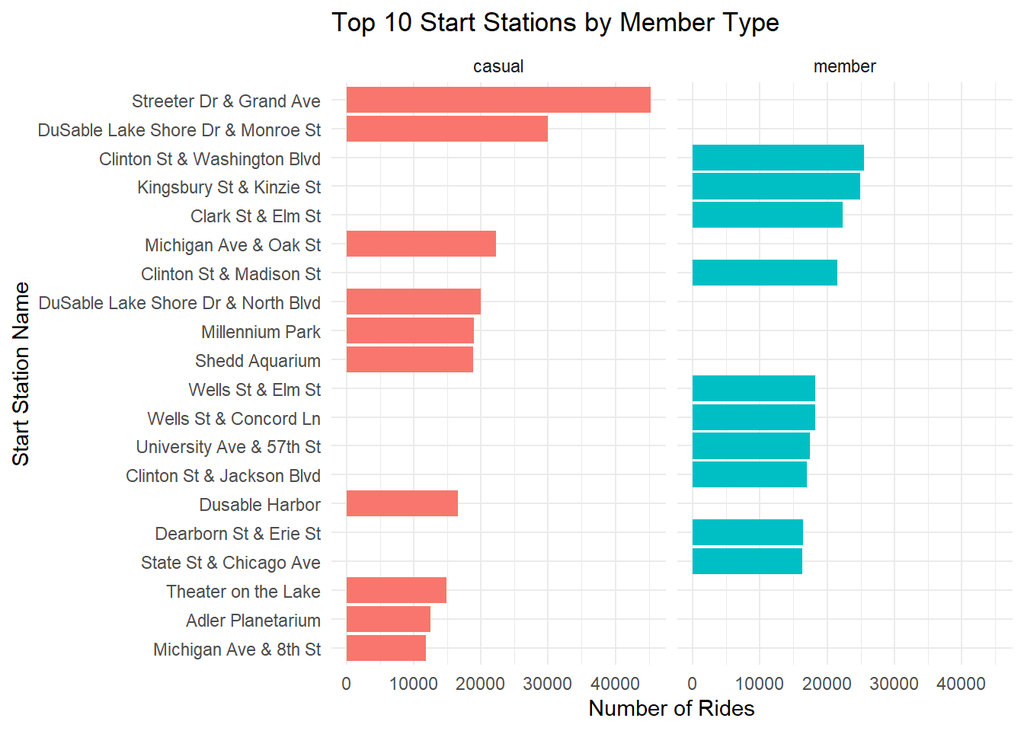

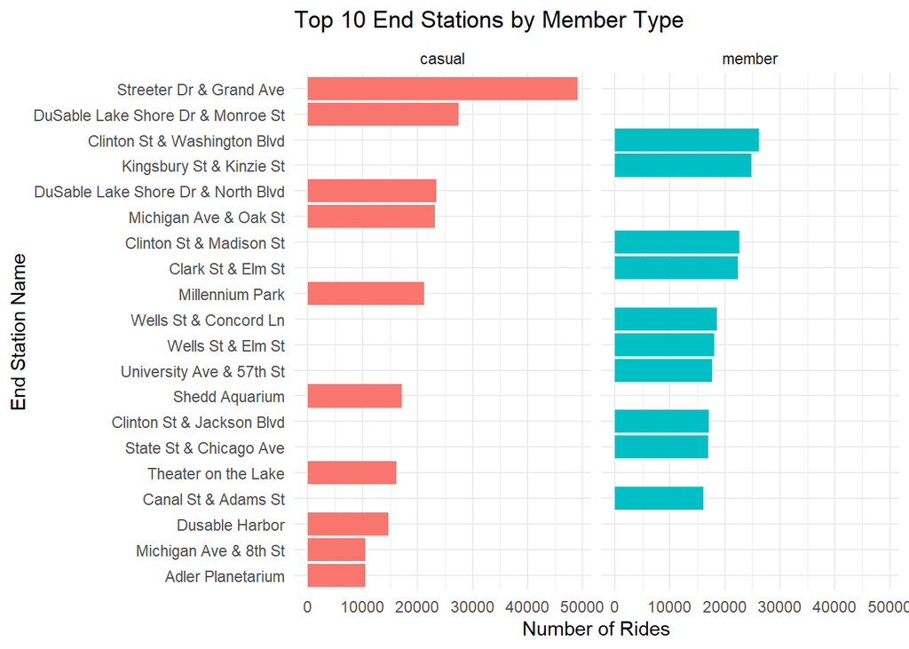

### 5. Ride Frequency by Day of the Week

The analysis of ride frequency by day of the week shows that bike usage is relatively high on weekdays, peaking in midweek. Saturdays and Sundays also see high usage, which could be indicative of leisure or recreational rides during the weekends.

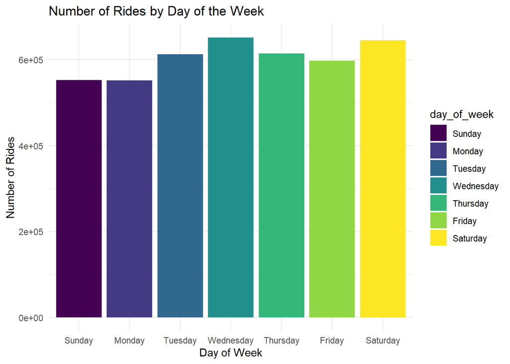

### 6. Member vs. Casual Usage Patterns

The analysis showed that casual riders have longer average ride durations for classic and docked bikes compared to annual members. Annual members have shorter ride durations across all bike types, suggesting more frequent but shorter trips.

A bar plot illustrates average ride duration by rideable type and member type.

```
## Defaulting to continuous.
```

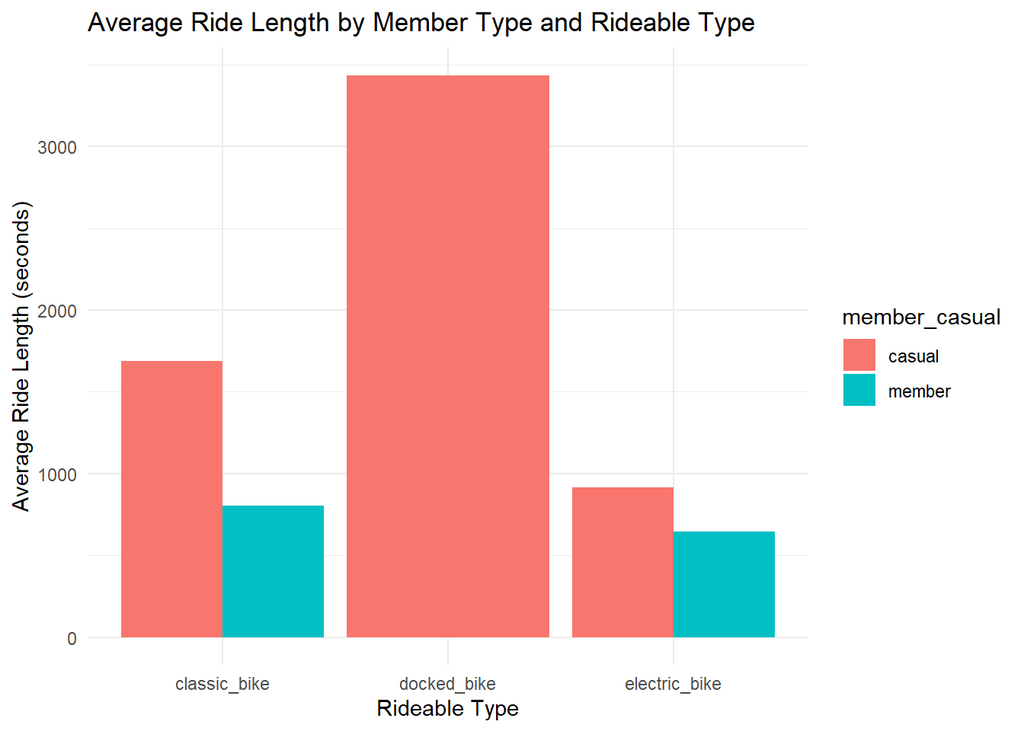

### 8. Average Ride Duration by Day of Week and Hour

The analysis of average ride duration by day of week and hour of the day provides insights into when riders take longer trips. For example:

- Ride durations vary significantly across different hours of the day and days of the week.
- Longer rides tend to occur during certain hours, indicating potential peak usage times or periods when riders may have more leisure time.

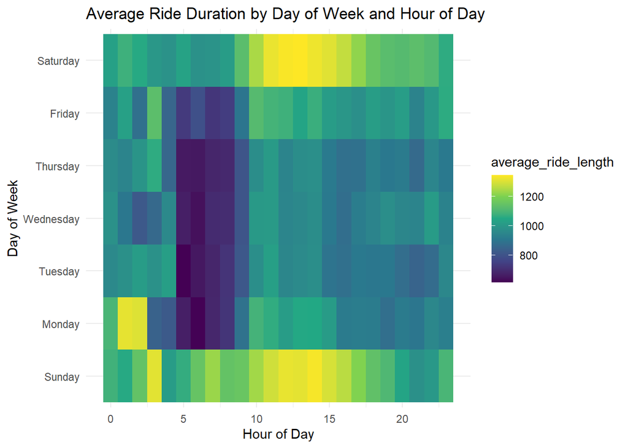

The heatmap visualization highlights these patterns, with brighter colors representing longer ride durations. This information can help optimize bike availability and identify times when additional support might be needed.

### 9. Monthly Ride Trends

Monthly ride trends reveal fluctuations in bike usage over the year:

The line graph demonstrates these trends, emphasizing the importance of adjusting marketing strategies and service levels according to seasonal demand.

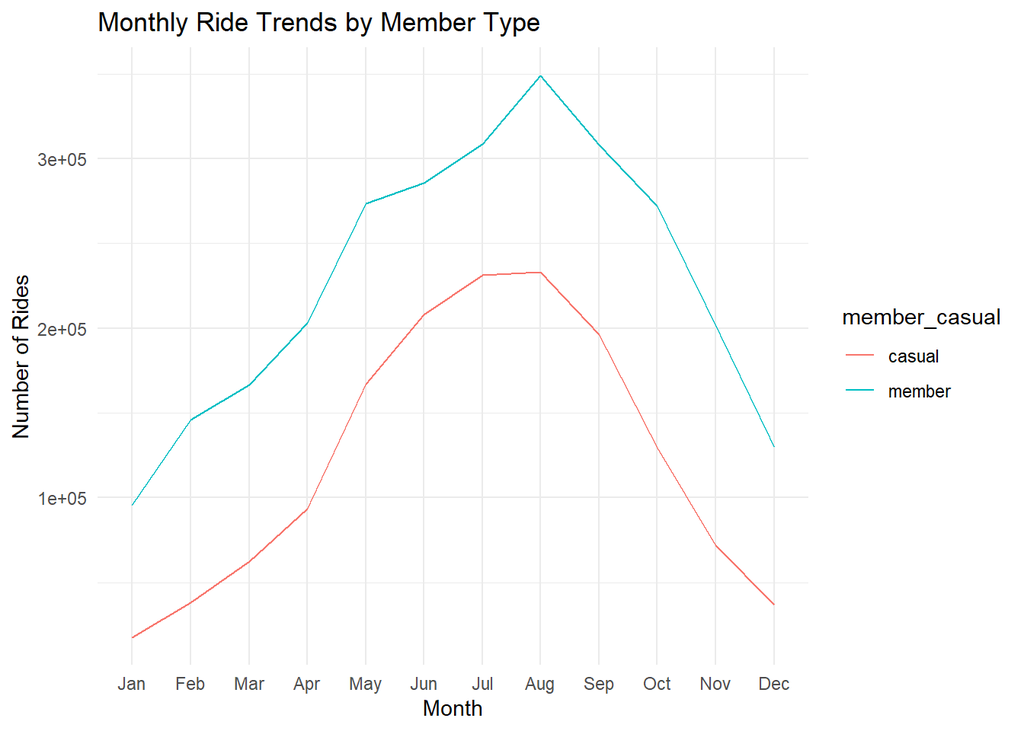

### 10. Average Ride Duration by Rideable Type

The comparison of average ride duration across different bike types and member categories shows:

- *Classic bikes* generally have a higher average ride duration compared to electric bikes.
- *Casual riders* tend to take longer trips on both classic and electric bikes compared to annual members.

This bar chart indicates that classic bikes are associated with longer rides, suggesting that they might be preferred for extended journeys.

```
## Defaulting to continuous.
```

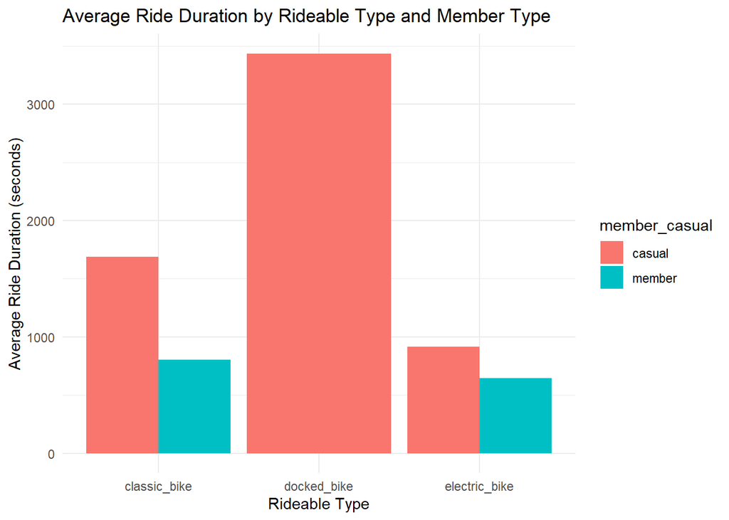

### 11. Station Utilization

The analysis of station utilization reveals the most popular bike stations:

Top 10 Most Utilized Stations

| start_station_name | station_rides | unique_bikes |
| --- | --- | --- |
| Streeter Dr & Grand Ave | 60022 | 60020 |
| DuSable Lake Shore Dr & Monroe St | 39309 | 39309 |
| Michigan Ave & Oak St | 35454 | 35453 |
| DuSable Lake Shore Dr & North Blvd | 34916 | 34916 |
| Kingsbury St & Kinzie St | 33038 | 33038 |
| Clark St & Elm St | 31726 | 31726 |
| Clinton St & Washington Blvd | 31150 | 31150 |
| Millennium Park | 28542 | 28541 |
| Wells St & Concord Ln | 27619 | 27612 |
| Clinton St & Madison St | 27470 | 27470 |

### Bike usage by time of year, rideable type, and member type

Analyzing the data on bike usage by time of year, rideable type, and member type, several key insights emerge that can shape our understanding of rider behavior:

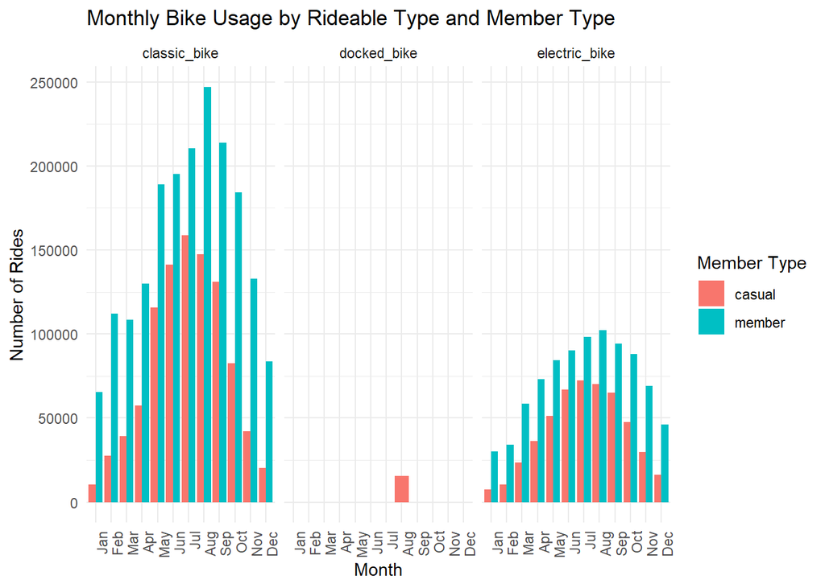

## Application of Insights

Use these insights to design targeted marketing strategies and improve service offerings. By understanding the patterns of usage, Cyclistic can offer tailored promotions to casual riders that encourage them to become annual members. Additionally, the company can optimize the availability of bike types according to the preferences and peak times of different rider groups.

## Next Steps

1. **Targeted Marketing Campaigns:** Develop and launch marketing campaigns that highlight the benefits of membership, particularly focusing on how it suits the casual riders’ usage patterns.
2. **Service Optimization:** Adjust bike availability and station resources to cater to the peak usage times and preferences identified in the analysis.
3. **Further Data Collection:** Consider collecting more detailed data on ride purpose and user demographics to refine the marketing strategies further.